[figure not shown]

Exploring cash use as a transit fare payment method  
in the Greater Seattle Area

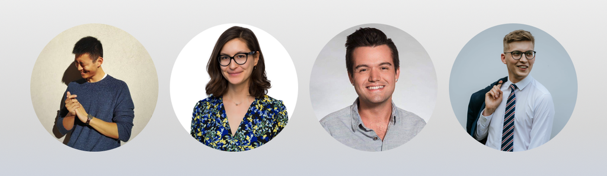

Produced by **‘Data Wizards’ Group**:  
*Haotian Bu, Aishe Memetova, Jon White, Vitalii Zakhozhyi*

**Contents:**

1. Introduction
2. Data Pre-processing
3. Question 1: To what extent is cash being used as the payment method for LINK transit fare?
4. Question 2: What type of fare is the most common given different purpose of trips and different income groups?
5. Question 3: What’s the effects of explanatory variables have on cash usage?
6. Finding & Conclusion

**Introduction and Data Summary**

**Introduction**

Our group is interested in exploring how frequently cash is used as a mean of paying for transit fare in the Greater Seattle area. This research project is drawn from the assumption that using cash to pay transit fare is inconvenient for both riders and transport service providers, and decreases the efficiency and speed of the transportation system. From the riders’ perspective, having exact change to pay for fare is inconvenient (especially considering that King County Metro’s Adult Fare is $2.75). From the service provider’s perspective, riders paying with cash increases the wait time and can cause delays in the schedule. Sound Transit requested this research to find out to what extent cash is still used in the Greater Seattle Area. They would also be interested in what populations are more likely to use cash for transit fare payment.

**Research Question**

The main research question is the following:

**Whether cash has a big stake as a payment method for transit fare amongst LINK riders in the Greater Seattle area. And, if so, who is most likely to pay transit fare with cash?**

**Data**

The data for this project comes from Sound Transit’s [“2015 Onboard Survey”](https://github.com/karllovepolicy/Data_Visual_Final_Tutorial/raw/master/OriginalData.csv), a survey conduct on the LINK light rail and Sound Transit busses; however, we narrowed down the data set to looking exclusively at LINK riders. The survey asked riders a variety of questions about their trip details and personal details (time of day of trip, purpose of trip, what mode of travel the rider used to get to public transit, the number of vehicles owned by the rider’s household, languages spoken in household, etc.). One of our group members had obtained this data from Sound Transit for a previous academic project and received approval from them to use it again for this project.

The full original dataset contains 134 variables and 3398 observations.

Our variable of interest is fare type (named as “faretype”), which means what method of payment was used by a rider to pay a transit fare. Later, we transform this variable into the dummy variable with the values (Cash/Not Cash), which we further use as the dependent variable for the regressin analysis to assess the impact of chosen explanatory variables on the likelihood of using cash as the transit fare payment method.

The independent variables we used for the research include:

- Purpose of the trip (“purpose”)
- Household Income (“income”)
- Vehicle in the household (“vehicle”)
- Number of trips made on any transit route in the region in the last month (“number_of_trips”)

The dataset has a lot of missing values. For the purpose of this research, we drop the whole observation if there is a missing value in one of the variables of interests.

Go back to the table of contents

**Data Pre-processing**

```r
knitr::opts_chunk$set(fig.width=12, fig.height=8)
```

First, we need to call the libraries to be able to use the necessary packages:

```r
library(ggplot2)
library(scales)
library(dplyr)
```

Then, we need to call the data we want to analyze. In our case we call the csv file “linkdata”:

```r
linkdata <- read.csv("https://raw.githubusercontent.com/karllovepolicy/Data_Visual_Final_Tutorial/master/OriginalData.csv", stringsAsFactors=FALSE)
str(linkdata)
```

Because some variable names from the original data set are not clear and easily interpreted, we change the names of some explanatory variables to something more accessible for a reader:

```r
#change names of explanatory variables
linkdata <- rename(linkdata,'number_of_trips'='oneway_all_clean', 'vehicle'='hhveh_clean', "income"="hhincome")
```

There is a lot of missing data (noted as #NULL) across the full dataset. Before getting rid of all of the observations that have missing values, we check the unique values of every variable of interest:

```r
unique(linkdata$faretype)
```

```
##  [1] "ORCA, as pass"          "ORCA e-purse"
##  [3] "Train Ticket, One Way"  "Cash"
##  [5] "U-PASS ORCA"            "FALSE"
##  [7] "#NULL!"                 "ORCA day pass"
##  [9] "Train Ticket, Day Pass" "Free"
## [11] "Police/Peace Officer"
```

We noticed “False” here which, according to Sound Transit’s provided coding guide, indicates the responde “Other”. We need to change “False” to “Other”:

```r
linkdata <- linkdata %>%
  mutate(faretype = recode(faretype, 'FALSE' = "Other"))
unique(linkdata$purpose)
```

```
## [1] "Home Based Non-Work Trip" "Home Based Work Trip"
## [3] "Non-home based trip"      "#NULL!"
```

```r
unique(linkdata$income)
```

```
##  [1] "$75,000-$99,999" "$20,000-$23,999" "$40,000-$48,999"
##  [4] "#NULL!"          "Under 12000"     "$57,000-$74,999"
##  [7] "$24,000-$31,999" "$100,000+"       "16,000-$19,999"
## [10] "$49,000-$56,999" "$32,000-$39,999" "12000-15999"
```

We noticed that some values of income are not consistently formatted across our full dataset; therefore, we unify the format of the values by recoding them. We also regroup income levels to 4 groups: lowest, medium-low, medium-high, and highest income.

```r
#the category of income need some work
linkdata <- linkdata %>% mutate(income = recode(income,
                                    "16,000-$19,999"="$16,000-$19,999",
                                    "12000-15999" ="$12,000-$15,999",
                                    "Under 12000"="Under $12,000"))
#regroup income levels based on Seattle 2015 Household Income Quantile, https://www.kingcounty.gov/independent/forecasting/King%20County%20Economic%20Indicators/Household%20Income/KC%20Household%20Income%20Quintiles.aspx
lowest_income <- c("Under $12000","$12,000-$15,999", "$16,000-$19,999", "$20,000-$23,999", "$24,000-$31,999", "$32,000-$39,999")
medium_low_income <- c("$40,000-$48,999", "$57,000-$74,999", "$49,000-$56,999")
medium_high_income <-c("$75,000-$99,999")
highest_income <- c("$100,000+")

linkdata <- linkdata %>% mutate(income = case_when(
  income %in% lowest_income~"lowest",
  income %in% medium_low_income~"medium_low",
  income %in% medium_high_income~"medium_high",
  income %in% highest_income~"highest"))
```

```r
unique(linkdata$vehicle)
```

```
## [1] "1"      "2"      "0"      "5"      "4"      "3"      "#NULL!"
```

```r
unique(linkdata$number_of_trips)
```

```
##  [1] "4"      "#NULL!" "14"     "16"     "40"     "5"      "30"
##  [8] "45"     "25"     "50"     "11"     "9"      "75"     "7"
## [15] "90"     "20"     "26"     "10"     "60"     "15"     "48"
## [22] "36"     "22"     "27"     "54"     "8"      "12"     "1"
## [29] "2"      "35"     "3"      "32"     "28"     "80"     "44"
## [36] "6"      "65"     "41"     "17"     "0"      "70"     "18"
## [43] "38"     "33"     "13"     "100"    "52"     "47"     "72"
## [50] "23"     "56"     "66"     "58"     "46"     "92"     "55"
## [57] "24"     "21"     "64"     "37"     "29"
```

Almost all the variables have some observations with missing data, so we drop those observations and create a new dataset in order to clean the dataset.

```r
mydata1 <- linkdata %>%
  filter(faretype != "#NULL!") %>%
  filter(purpose != "#NULL!") %>%
  filter(income != "NA") %>%
  filter(vehicle != "#NULL!") %>%
  filter(number_of_trips != "#NULL!")
```

The format of some variables still needs to be changed.

```r
# these variable are all characters, we need to transform, some to numeric, some to factor
mydata1$vehicle <- as.numeric(mydata1$vehicle)
# subset, transform faretype and vehicle binary variables, select needed variables:
mydata2 <- mydata1 %>% mutate(cashlove = ifelse(faretype=="Cash", 1, 0), vehicle = ifelse(vehicle>0, 1, 0)) %>% select(faretype, cashlove, purpose, income,  vehicle, number_of_trips)

#mydata2$faretype <- factor(mydata2$faretype)

# set the right type for dependent variable
#from num to factor
mydata2$cashlove <- factor(mydata2$cashlove)

# set the correct type for explanatory variables
#reset the level of variable "purpose"
mydata2$purpose <- factor(mydata2$purpose)
#from cha to factor, set right level for factor
mydata2$income <- factor(mydata2$income)
incomelevel <- c("lowest","medium_low","medium_high","highest")
mydata2$income <- factor(mydata2$income, levels=incomelevel)
#from num to factor
mydata2$vehicle <- factor(mydata2$vehicle)
#from cha to numeric
mydata2$number_of_trips <- as.numeric(mydata2$number_of_trips)#-1

head(mydata2,5)
```

```
##        faretype cashlove                  purpose      income vehicle
## 1 ORCA, as pass        0 Home Based Non-Work Trip medium_high       1
## 2  ORCA e-purse        0     Home Based Work Trip medium_high       1
## 3 ORCA, as pass        0     Home Based Work Trip  medium_low       0
## 4 ORCA, as pass        0 Home Based Non-Work Trip  medium_low       1
## 5 ORCA, as pass        0 Home Based Non-Work Trip  medium_low       0
##   number_of_trips
## 1               4
## 2              14
## 3              40
## 4               5
## 5              30
```

```r
# transform explanatory varibles from factor to numeric, add "-1" in command because Factors in R are represented internally as integers and the first factor is 1.
```

With the cleaning and pre-processing of the data complete, we are left with a subset of: 6 variables of interest and 778 completed observations.

```r
str(mydata2)
```

```
## 'data.frame':    778 obs. of  6 variables:
##  $ faretype       : chr  "ORCA, as pass" "ORCA e-purse" "ORCA, as pass" "ORCA, as pass" ...
##  $ cashlove       : Factor w/ 2 levels "0","1": 1 1 1 1 1 1 1 1 1 1 ...
##  $ purpose        : Factor w/ 3 levels "Home Based Non-Work Trip",..: 1 2 2 1 1 2 2 2 1 1 ...
##  $ income         : Factor w/ 4 levels "lowest","medium_low",..: 3 3 2 2 2 1 4 2 1 4 ...
##  $ vehicle        : Factor w/ 2 levels "0","1": 2 2 1 2 1 1 2 1 1 1 ...
##  $ number_of_trips: num  4 14 40 5 30 45 25 50 11 9 ...
```

Now that we have a cleaned data subset with desired formatting, we save this subset as a “.csv file” in order to use it for further analysis.

```r
write.csv(mydata2, file = "FinalData.csv")
```

Go back to the table of contents

**Question 1: To what extent is cash being used as the payment method for LINK transit fare?**

We start our analysis by discussing how frequently different payment methods of LINK transit fare are used. The first question we need to answer is “to what extent cash is cash being used as the payment method for LINK transit fare?”

To answer this question, we can build a univariate plot, showing the proportions of use of different payment methods.

We will use the “ggplot2” package to build our plots. This package builds plots using “data frames” so, before building the plot, we need to create the data frame of fare type frequencies:

```r
absol_ft=table(mydata2$faretype, exclude = 'nothing')
ft_freq=prop.table(absol_ft)*100
ft_freq_df=as.data.frame(ft_freq)
names(ft_freq_df)=c("faretype","pct")

#the real sequence of factor varibale is different from it appeared in dataframe, reorder() command from high to low, order() command from low to high

#set the order for table
ft_freq_df <- ft_freq_df[order(ft_freq_df$pct),]
ft_freq_df
```

```
##                 faretype        pct
## 2                   Free  0.2570694
## 6                  Other  0.3856041
## 7 Train Ticket, Day Pass  0.6426735
## 3          ORCA day pass  1.5424165
## 8  Train Ticket, One Way  4.6272494
## 1                   Cash  4.7557841
## 9            U-PASS ORCA  6.5552699
## 4           ORCA e-purse 23.7789203
## 5          ORCA, as pass 57.4550129
```

Now we can build a bar plot to visualize how frequently each of the payment methods is used. Since our primary focus is cash, we want to highlight it by using the green color for the bar that represents “cash”.

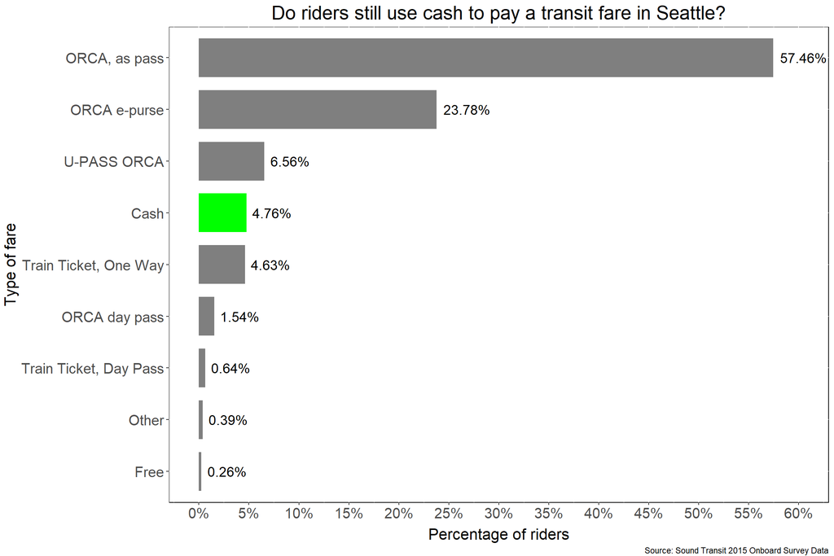

```r
#set the specific color for cash
cashasred <- scale_fill_manual(values=c("Cash" = "green","Free"="gray50","Other"="gray50","Train Ticket, Day Pass"="gray50","ORCA day pass"="gray50","Train Ticket, One Way"="gray50","U-PASS ORCA"="gray50","ORCA e-purse"="gray50","ORCA, as pass"="gray50"))

base = ggplot(ft_freq_df, aes(x=reorder(faretype, pct), y=pct, fill=faretype))
ft_plot1 = base + geom_bar(stat="identity", width = 0.75) + cashasred
ft_plot2 = ft_plot1 + labs(title='Do riders still use cash to pay a transit fare in Seattle?', #to label the graph
                           x ='Type of fare',
                           y = 'Percentage of riders',
                           caption = 'Source: Sound Transit 2015 Onboard Survey Data')
ft_plot3 = ft_plot2 + coord_flip() + scale_y_continuous(limits=c(0,60),
                                     breaks = seq(0, 60, by = 5),
                                     labels=unit_format(suffix = '%')) +
                            scale_x_discrete(limits=ft_freq_df$faretype)
ft_plot4 = ft_plot3 + geom_text(aes(y = pct,
                                label = paste0(round(pct,2), '%')),
                                hjust= -0.15,
                                size = 5)
ft_plot5 = ft_plot4 + theme(panel.background = element_rect(fill = "white", color = "black"),
                            legend.position = "none",
                            plot.title = element_text(size = 20, hjust = 0.5),
                            plot.caption = element_text(hjust = 1, vjust = -1.2),
                            axis.text.x  = element_text(size=15),
                            axis.text.y  = element_text(size=15),
                            axis.title.y = element_text(size = 16, hjust = 0.5, vjust = 1.75),
                            axis.title.x = element_text(size = 16, hjust = 0.5, vjust = -1.25))
ft_plot5
```

From the plot, we can see that almost 5% of the population were using cash to pay transit fare to ride LINK in 2015. Generally speaking, this is not a big percentage of the LINK ridership population. In comparison, the percentage for use of different types of ORCA cards/payments varies from 1.54% (ORCA day pass) to 57.5% (ORCA as pass). In total, the various forms of ORCA payment methods represented almost 90% of all payment methods used.

If the goal is to reduce the payments with cash, the current stake of 5% seems like a good result. However, there is still room for improvement. Therefore, it is interesting to know which people are most likely to use cash, what their income levels are likely to be, what their trip are, etc.

**Question 2: What type of fare is the most common given different purpose of trips and different income groups?**

Now, we will try to answer what type of fare is the most common given different purpose of trips and different income groups.

Cleaning the data and creating the proportion table for faretype VS. Purpose

We will first need to clean the data so that there are no missing values.

```r
FarePurpose=table(mydata2$faretype, mydata2$purpose)%>%
         prop.table(margin = 2)%>%   # 2 is % by column
         "*"(100)%>%
         round(3)
```

Same as with the barplot, we will need to create a data frame

```r
dfFarePurpose=as.data.frame(FarePurpose)
names(dfFarePurpose)=c('Faretype','Purpose','Percent')

#the real sequence of factor varibale is different from it appeared in dataframe, reorder() command from high to low, order() command from low to high

#set the order for table
dfFarePurpose <- dfFarePurpose[order(dfFarePurpose$Purpose, dfFarePurpose$Percent),]
dfFarePurpose
```

```
##                  Faretype                  Purpose Percent
## 2                    Free Home Based Non-Work Trip   0.000
## 7  Train Ticket, Day Pass Home Based Non-Work Trip   0.375
## 6                   Other Home Based Non-Work Trip   0.749
## 3           ORCA day pass Home Based Non-Work Trip   1.498
## 1                    Cash Home Based Non-Work Trip   5.993
## 8   Train Ticket, One Way Home Based Non-Work Trip   6.367
## 9             U-PASS ORCA Home Based Non-Work Trip  10.487
## 4            ORCA e-purse Home Based Non-Work Trip  28.090
## 5           ORCA, as pass Home Based Non-Work Trip  46.442
## 15                  Other     Home Based Work Trip   0.000
## 11                   Free     Home Based Work Trip   0.275
## 16 Train Ticket, Day Pass     Home Based Work Trip   0.275
## 17  Train Ticket, One Way     Home Based Work Trip   0.275
## 12          ORCA day pass     Home Based Work Trip   0.551
## 10                   Cash     Home Based Work Trip   1.377
## 18            U-PASS ORCA     Home Based Work Trip   5.234
## 13           ORCA e-purse     Home Based Work Trip  22.314
## 14          ORCA, as pass     Home Based Work Trip  69.697
## 20                   Free      Non-home based trip   0.676
## 24                  Other      Non-home based trip   0.676
## 25 Train Ticket, Day Pass      Non-home based trip   2.027
## 27            U-PASS ORCA      Non-home based trip   2.703
## 21          ORCA day pass      Non-home based trip   4.054
## 19                   Cash      Non-home based trip  10.811
## 26  Train Ticket, One Way      Non-home based trip  12.162
## 22           ORCA e-purse      Non-home based trip  19.595
## 23          ORCA, as pass      Non-home based trip  47.297
```

**Building the faretype VS. Purpose plot**

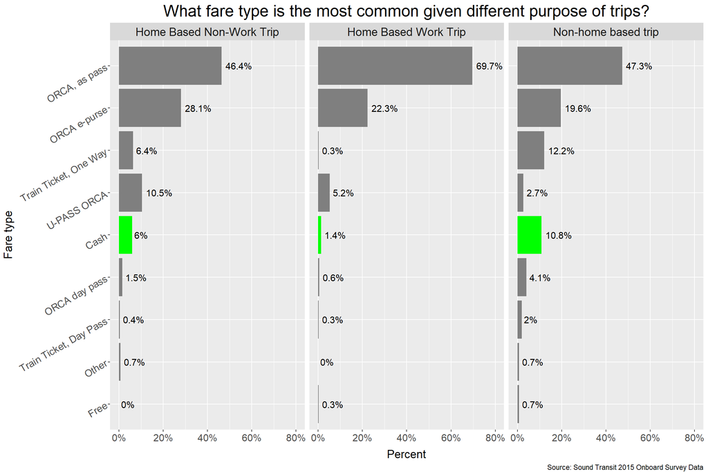

```r
base  = ggplot(dfFarePurpose, aes(x = reorder(Faretype, Percent), y = Percent, fill=Faretype))
bars1 = base + geom_bar(stat = "identity")+cashasred
bars2 = bars1 + facet_wrap( ~ Purpose ,nrow = 1)
bars3 = bars2 + coord_flip() +
                scale_y_continuous(limits=c(0,80),
                                  labels=scales::unit_format(suffix = '%'))
bars4 = bars3 + geom_text(aes(y = Percent,
                                  label = paste0(round(Percent,1), '%')),
                                  hjust= -0.15,
                                  size = 4)
bars5 = bars4 + labs(title='What fare type is the most common given different purpose of trips?',
                     x ='Fare type',
                     caption = 'Source: Sound Transit 2015 Onboard Survey Data')
bars6 = bars5 + theme(axis.text.y = element_text(size=12, angle = 30),
                      axis.text.x = element_text(size=12),
                      legend.position = "none",
                      plot.title = element_text(size = 20, hjust = 0.5),
                      plot.caption = element_text(hjust = 1, vjust = -1.2),
                      axis.title.y = element_text(size = 14, hjust = 0.5, vjust = 1.75),
                      axis.title.x = element_text(size = 14, hjust = 0.5, vjust = -1.25),
                      strip.text = element_text(size = 14))
bars6
```

As we can see from the barplot, cash is more likely to be used for non-home based trips and for home based non-work trips. It makes sense, given the fact that people can use cash for one-time trip or they are not living in the area.

Lets do the same with the income variable.

**Cleaning the data and creating the proportion table for faretype VS. Income**

```r
FareIncome=table(mydata2$faretype, mydata2$income)%>%
         prop.table(margin = 2)%>%   # 2 is % by column
         "*"(100)%>%
         round(3)
```

Same as with the barplot, we will need to create a data frame

```r
dfFareIncome=as.data.frame(FareIncome)
names(dfFareIncome)=c('Faretype','Income','Percent')
dfFareIncome
```

```
##                  Faretype      Income Percent
## 1                    Cash      lowest   6.180
## 2                    Free      lowest   0.000
## 3           ORCA day pass      lowest   1.124
## 4            ORCA e-purse      lowest  26.966
## 5           ORCA, as pass      lowest  54.494
## 6                   Other      lowest   0.562
## 7  Train Ticket, Day Pass      lowest   1.124
## 8   Train Ticket, One Way      lowest   3.371
## 9             U-PASS ORCA      lowest   6.180
## 10                   Cash  medium_low   4.472
## 11                   Free  medium_low   0.000
## 12          ORCA day pass  medium_low   1.626
## 13           ORCA e-purse  medium_low  20.732
## 14          ORCA, as pass  medium_low  63.008
```

[output cut: 22 more lines]

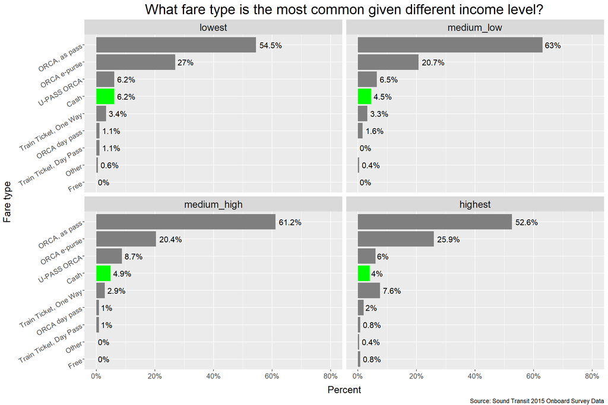

```r
base  = ggplot(dfFareIncome, aes(x = reorder(Faretype, Percent), y = Percent, fill=Faretype))
bars1 = base + geom_bar(stat = "identity") + cashasred
bars2 = bars1 + facet_wrap( ~Income,nrow = 3)
bars3 = bars2 + coord_flip() +
                scale_y_continuous(limits=c(0,80),
                                  labels=scales::unit_format(suffix = '%'))
bars4 = bars3 + geom_text(aes(y = Percent,
                                  label = paste0(round(Percent,1), '%')),
                                  hjust= -0.15,
                                  size = 4)
bars5 = bars4 + labs(title='What fare type is the most common given different income level?',
                     x ='Fare type',
                     caption = 'Source: Sound Transit 2015 Onboard Survey Data')
bars6 = bars5 + theme(axis.text.y = element_text(size=10, angle = 30),
                      axis.text.x = element_text(size=10),
                      legend.position = "none",
                      plot.title = element_text(size = 20, hjust = 0.5),
                      plot.caption = element_text(hjust = 1, vjust = -1.2),
                      axis.title.y = element_text(size = 14, hjust = 0.5, vjust = 1.75),
                      axis.title.x = element_text(size = 14, hjust = 0.5, vjust = -1.25),
                      strip.text = element_text(size = 14))
bars6
```

Go back to the table of contents

**Question 3: What’s the effects of explanatory variables have on cash usage?**

Next step is assessing the impact of explanatory variables on cash usage.

In this section, we will explore the realationship among the probability of using cash for this trip, whether people have vehicles, the purpose of this trip, and frequency of using public transportation.

Given our variables and theory, the methodology we will use is the logistical regression.

**Doing Regression with logit model**

Our reference group is people who has lowest income, whose purpose of this trip is home-based non-work trip and don’t have vehicles at home.

```r
mydata2 <- within(mydata2, income <- relevel(income, ref = "lowest"))
mydata2 <- within(mydata2, purpose <- relevel(purpose, ref = "Home Based Non-Work Trip"))
```

```r
library(dotwhisker)
library(broom)
#just use purpose as explantary variable
mylogit1 <- glm(cashlove ~ purpose, data = mydata2, family = "binomial")
model1 = tidy(mylogit1) %>%   # we save the result as a tidy object and...
    mutate(model = "Model 1")
#use
mylogit2 <- glm(cashlove ~ purpose + vehicle, data = mydata2, family = "binomial")
model2 = tidy(mylogit2) %>%   # we save the result as a tidy object and...
    mutate(model = "Model 2")
#use
mylogit3 <- glm(cashlove ~ purpose + vehicle +number_of_trips, data = mydata2, family = "binomial")
model3 = tidy(mylogit3) %>%   # we save the result as a tidy object and...
    mutate(model = "Model 3")
#use
mylogit4 <- glm(cashlove ~ purpose + vehicle + number_of_trips + income, data = mydata2, family = "binomial")
model4 = tidy(mylogit4) %>%   # we save the result as a tidy object and...
    mutate(model = "Model 4")
summary(mylogit4)
```

```
##
## Call:
## glm(formula = cashlove ~ purpose + vehicle + number_of_trips +
##     income, family = "binomial", data = mydata2)
##
## Deviance Residuals:
##     Min       1Q   Median       3Q      Max
## -0.9039  -0.3534  -0.1983  -0.1099   3.0689
##
## Coefficients:
##                             Estimate Std. Error z value Pr(>|z|)
## (Intercept)                 -1.84176    0.58791  -3.133 0.001732 **
## purposeHome Based Work Trip -1.18202    0.53060  -2.228 0.025901 *
## purposeNon-home based trip   0.64737    0.38528   1.680 0.092902 .
## vehicle1                     0.51047    0.58937   0.866 0.386422
## number_of_trips             -0.05801    0.01623  -3.574 0.000351 ***
## incomemedium_low            -0.53525    0.47188  -1.134 0.256663
## incomemedium_high           -0.73027    0.59099  -1.236 0.216583
## incomehighest               -1.11556    0.49094  -2.272 0.023070 *
## ---
## Signif. codes:  0 '***' 0.001 '**' 0.01 '*' 0.05 '.' 0.1 ' ' 1
##
## (Dispersion parameter for binomial family taken to be 1)
##
##     Null deviance: 297.6  on 777  degrees of freedom
## Residual deviance: 250.6  on 770  degrees of freedom
## AIC: 266.6
##
## Number of Fisher Scoring iterations: 7
```

**Comparing four models**

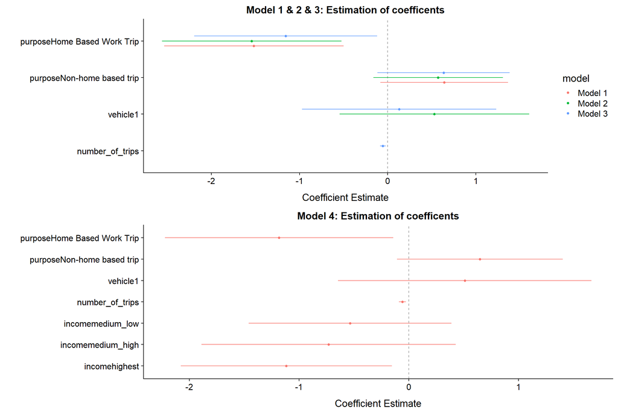

```r
library(cowplot)
library(gridExtra)
allModels=rbind(model1, model2, model3)


dwplot1<-dwplot(allModels, vline = geom_vline(xintercept = 0, colour = "grey60", linetype = 2)) +
  xlab("Coefficient Estimate") +
  ylab("") +
  ggtitle("Model 1 & 2 & 3: Estimation of coefficents") +
  theme(axis.text.y = element_text(size=12, angle = 0),
        axis.text.x = element_text(size=12),
        plot.title = element_text(size = 14, hjust = 0.5),
        plot.caption = element_text(hjust = 1, vjust = -1.2),
        axis.title.y = element_text(size = 14, hjust = 0.5, vjust = 1.75),
        axis.title.x = element_text(size = 14, hjust = 0.5, vjust = -1.25))

dwplot2<-dwplot(model4, vline = geom_vline(xintercept = 0, colour = "grey60", linetype = 2)) +
  xlab("Coefficient Estimate") +
  ylab("") +
  ggtitle("Model 4: Estimation of coefficents") +
  theme(axis.text.y = element_text(size=12, angle = 0),
        axis.text.x = element_text(size=12),
        plot.title = element_text(size = 14, hjust = 0.5),
        plot.caption = element_text(hjust = 1, vjust = -1.2),
        axis.title.y = element_text(size = 14, hjust = 0.5, vjust = 1.75),
        axis.title.x = element_text(size = 14, hjust = 0.5, vjust = -1.25))

grid.arrange(dwplot1,dwplot2, ncol=1)
```

Go back to the table of contents

**Findings & Conclusion**

From our regression, we can see that compared with reference group, people in the highest income group are less likely to use cash to pay transit fees, people whose purpose is home based work trip have less probability using cash. The more trips people have in each month, the less likelihood people would use cash. However, the difference on cash usage between people who have vehicles in home and people who don’t is not significant.

Go back to top of the page

Go back to the table of contents

[Go to the Project Repo](https://github.com/karllovepolicy/Data_Visual_Final_Tutorial)